# Staggered Adoption Panel Event Study

This vignette uses the Hainmueller–Hangartner municipal naturalization panel from the local `FTestEventStudy` sandbox to exercise the matrix panel API on real staggered-adoption data.

The public crabbymetrics panel estimators use a deliberately small contract:

```
fit(Y, W)
```

where `Y` is an `(n_units, n_periods)` outcome matrix and `W` is a same-shaped absorbing binary treatment matrix. Here the outcome is the ordinary naturalization rate (`nat_rate_ord`) and the treatment is the indirect-democracy adoption indicator (`indirect`).

We also compare two pyfixest event-study baselines:

- a vanilla binned two-way fixed-effects event study with municipality and year effects;
- the pyfixest saturated event-study interface, which is the Sun-Abraham-style cohort-by-event-time specification aggregated back to event time.

The source data are not vendored into this repository. The page is rendered locally from Apoorva’s research sandbox and the rendered HTML is pushed with the docs.

## 1 Load The Panel

```python
from pathlib import Path
import re

import matplotlib.pyplot as plt
import numpy as np
import pandas as pd
import pyfixest as pf

from crabbymetrics import HorizontalPanelRidge, MatrixCompletion, SyntheticDID

DATA = Path(
    "/Users/alal/Dropbox/1_Research/metrics_sandbox/"
    "FTestEventStudy/example/hh2019/hh2019.csv"
)

if not DATA.exists():
    raise FileNotFoundError(
        "Expected the Hainmueller--Hangartner panel at "
        f"{DATA}. Set DATA to the local hh2019.csv path before rendering."
    )

df = pd.read_csv(DATA).drop(columns=["Unnamed: 0"], errors="ignore")
first_treated = df[df["indirect"].eq(1)].groupby("bfs")["year"].min()
df["g"] = df["bfs"].map(first_treated).fillna(0).astype(int)

print(df.head())
print("rows:", len(df), "units:", df["bfs"].nunique(), "years:", df["year"].nunique())
```

```
   bfs  year  nat_rate_ord  indirect     g
0    1  1991      0.000000         0  2006
1    1  1992      0.000000         0  2006
2    1  1993      0.000000         0  2006
3    1  1994      3.448276         0  2006
4    1  1995      0.000000         0  2006
rows: 22971 units: 1209 years: 19
```

## 2 Build `Y` And `W`

The panel is balanced. We pivot to matrices, infer each municipality’s first treatment year, and keep a copy of the full treatment matrix for the adoption plot.

```python
Ydf = df.pivot(index="bfs", columns="year", values="nat_rate_ord").sort_index()
Wdf = df.pivot(index="bfs", columns="year", values="indirect").sort_index()

years = np.asarray(Ydf.columns)
Y_all = Ydf.to_numpy(float)
W_all = Wdf.to_numpy(int)

ever_treated = W_all.sum(axis=1) > 0
first_idx_all = np.where(ever_treated, W_all.argmax(axis=1), -1)
first_year_all = np.where(
    first_idx_all >= 0,
    years[np.clip(first_idx_all, 0, len(years) - 1)],
    np.nan,
)

print("Y shape:", Y_all.shape)
print("W shape:", W_all.shape)
print("ever treated:", int(ever_treated.sum()))
print("never treated:", int((~ever_treated).sum()))
print("already treated in first period:", int((first_idx_all == 0).sum()))
```

```
Y shape: (1209, 19)
W shape: (1209, 19)
ever treated: 797
never treated: 412
already treated in first period: 283
```

The crabbymetrics panel estimators require at least one pre-treatment period for each treated cohort. The HH panel has many municipalities already treated in 1991, so the estimator sample drops those baseline-treated units. They still appear in the adoption-pattern panel.

```python
estimator_sample = first_idx_all != 0
Y = Y_all[estimator_sample]
W = W_all[estimator_sample].astype(float)
est_df = df[df["g"] != int(years[0])].copy()

print("estimator Y shape:", Y.shape)
print("treated units in estimator sample:", int((W.sum(axis=1) > 0).sum()))
print("control units in estimator sample:", int((W.sum(axis=1) == 0).sum()))
```

```
estimator Y shape: (926, 19)
treated units in estimator sample: 514
control units in estimator sample: 412
```

## 3 Panel 1: Adoption Pattern

The first panel sorts municipalities by their first treatment period and then shows the absorbing treatment matrix.

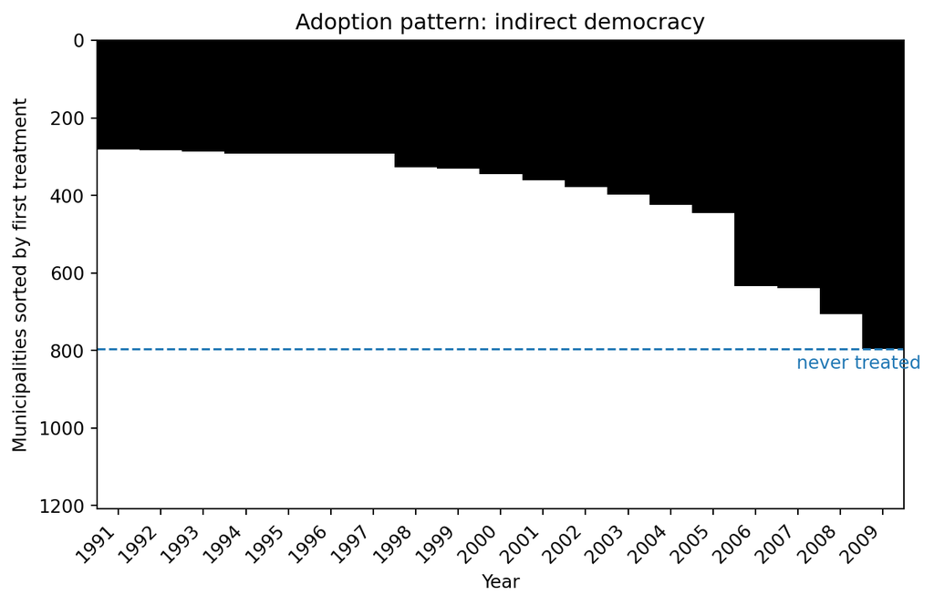

```python
sort_key = np.where(first_idx_all >= 0, first_idx_all, 999)
unit_order = np.lexsort((np.arange(len(sort_key)), sort_key))
W_sorted = W_all[unit_order]
never_start = np.searchsorted(np.sort(sort_key), 999)

fig, ax = plt.subplots(figsize=(7.0, 4.5), constrained_layout=True)
ax.imshow(W_sorted, aspect="auto", interpolation="nearest", cmap="Greys", vmin=0, vmax=1)
ax.set_title("Adoption pattern: indirect democracy")
ax.set_xlabel("Year")
ax.set_ylabel("Municipalities sorted by first treatment")
ax.set_xticks(np.arange(len(years)))
ax.set_xticklabels(years, rotation=45, ha="right")
ax.axhline(never_start - 0.5, color="tab:blue", lw=1.2, ls="--")
ax.text(len(years) - 0.1, never_start + 15, "never treated", color="tab:blue", ha="right", va="top")
plt.show()
```

## 4 Panel 2: Cohort Counts

The second panel counts municipalities by first treatment year.

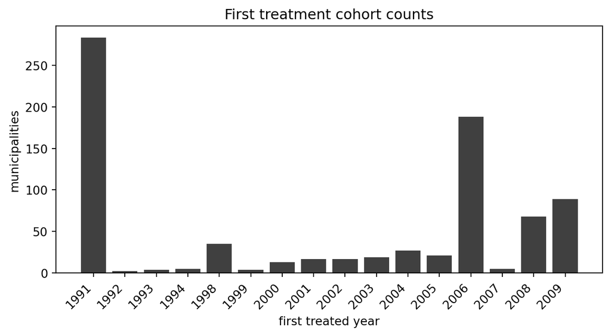

```python
cohort_counts = (
    pd.Series(first_year_all[~np.isnan(first_year_all)].astype(int))
    .value_counts()
    .sort_index()
)

fig, ax = plt.subplots(figsize=(7.0, 3.8), constrained_layout=True)
ax.bar(np.arange(len(cohort_counts)), cohort_counts.values, color="0.25")
ax.set_title("First treatment cohort counts")
ax.set_ylabel("municipalities")
ax.set_xlabel("first treated year")
ax.set_xticks(np.arange(len(cohort_counts)))
ax.set_xticklabels(cohort_counts.index.astype(str), rotation=45, ha="right")
plt.show()
```

## 5 Fit The crabbymetrics Panel Estimators

`HorizontalPanelRidge`, `MatrixCompletion`, and `SyntheticDID` all consume the same `(Y, W)` matrices and expose fitted summaries with `att`, `counterfactual`, `treatment_effect`, `group_means`, and `event_study` entries. For `SyntheticDID`, the event-study path is the period-by-period unit-weighted synthetic-control gap path; the time weights enter the scalar SDID `att` through the before/after contrast.

```python
crabby_estimators = {
    "HorizontalPanelRidge": HorizontalPanelRidge(1.0),
    "MatrixCompletion": MatrixCompletion(max_iterations=200, tolerance=1e-5),
    "SyntheticDID": SyntheticDID(),
}

crabby_results = {}
for name, estimator in crabby_estimators.items():
    estimator.fit(Y, W)
    summary = estimator.summary()
    event = summary["event_study"]["weighted"]
    crabby_results[name] = {
        "att": float(summary["att"]),
        "event_time": np.asarray(event["event_time"], float),
        "estimate": np.asarray(event["estimate"], float),
        "n": np.asarray(event["n"], float),
    }

for name, result in crabby_results.items():
    print(f"{name}: ATT = {result['att']:.3f}")
```

```
HorizontalPanelRidge: ATT = 2.515
MatrixCompletion: ATT = 1.475
SyntheticDID: ATT = 1.422
```

## 6 Panel 3: crabbymetrics Event Studies

The third panel overlays the weighted event-study summaries from the crabbymetrics panel estimators. These summaries are point estimates only; the core panel estimators do not report event-study standard-error bands.

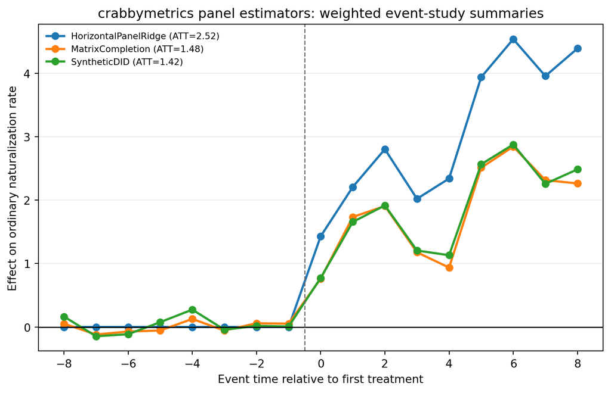

```python
colors = {
    "HorizontalPanelRidge": "tab:blue",
    "MatrixCompletion": "tab:orange",
    "SyntheticDID": "tab:green",
}

fig, ax = plt.subplots(figsize=(7.5, 4.8), constrained_layout=True)
for name, result in crabby_results.items():
    mask = (
        (result["event_time"] >= -8)
        & (result["event_time"] <= 8)
        & (result["n"] >= 10)
    )
    ax.plot(
        result["event_time"][mask],
        result["estimate"][mask],
        marker="o",
        lw=2,
        color=colors[name],
        label=f"{name} (ATT={result['att']:.2f})",
    )
ax.axhline(0, color="black", lw=1)
ax.axvline(-0.5, color="0.4", lw=1, ls="--")
ax.set_title("crabbymetrics panel estimators: weighted event-study summaries")
ax.set_xlabel("Event time relative to first treatment")
ax.set_ylabel("Effect on ordinary naturalization rate")
ax.grid(axis="y", alpha=0.25)
ax.legend(frameon=False, fontsize=8, loc="upper left")
plt.show()
```

## 7 Fit pyfixest Event-Study Baselines

For comparison, use pyfixest in two ways.

First, estimate a vanilla binned two-way fixed-effects event study with municipality and year fixed effects. Event time `-1` is the reference period, never-treated municipalities are retained, and municipality-clustered standard errors give the interval bands.

```python
est_df["rel"] = np.where(est_df["g"] > 0, est_df["year"] - est_df["g"], -999)
est_df["rel_bin"] = est_df["rel"].clip(-8, 8).astype(int).astype(str)
est_df.loc[est_df["g"] == 0, "rel_bin"] = "never"

twfe_fit = pf.feols(
    'nat_rate_ord ~ i(rel_bin, ref="-1") | bfs + year',
    data=est_df,
    vcov={"CRV1": "bfs"},
)

twfe_tidy = twfe_fit.tidy().reset_index().rename(columns={"Coefficient": "term"})


def parse_rel_time(term):
    match = re.search(r"rel_bin::(-?\d+)", str(term))
    return int(match.group(1)) if match else None


twfe_rows = []
for _, row in twfe_tidy.iterrows():
    event_time = parse_rel_time(row["term"])
    if event_time is not None:
        twfe_rows.append(
            {
                "event_time": event_time,
                "estimate": row["Estimate"],
                "lower": row["2.5%"],
                "upper": row["97.5%"],
            }
        )

twfe_event = pd.DataFrame(twfe_rows)
twfe_event = pd.concat(
    [
        twfe_event,
        pd.DataFrame([{"event_time": -1, "estimate": 0.0, "lower": 0.0, "upper": 0.0}]),
    ],
    ignore_index=True,
).sort_values("event_time")

print(twfe_event.head())
```

```
   event_time  estimate     lower     upper
6          -8 -0.263371 -0.795397  0.268655
5          -7 -0.696516 -1.293030 -0.100002
4          -6 -0.559682 -1.183254  0.063889
3          -5 -0.542962 -1.150822  0.064899
2          -4  0.086122 -0.589769  0.762013
```

Second, use `pyfixest.event_study(..., estimator="saturated")`. This estimates the saturated cohort-by-event-time specification and aggregates the coefficients back to event time.

```python
sa_fit = pf.event_study(
    est_df,
    yname="nat_rate_ord",
    idname="bfs",
    tname="year",
    gname="g",
    estimator="saturated",
    att=False,
    cluster="bfs",
)

sa_event = (
    sa_fit.aggregate()
    .reset_index()
    .rename(
        columns={
            "period": "event_time",
            "Estimate": "estimate",
            "2.5%": "lower",
            "97.5%": "upper",
        }
    )[["event_time", "estimate", "lower", "upper"]]
)
sa_event = pd.concat(
    [
        sa_event,
        pd.DataFrame([{"event_time": -1.0, "estimate": 0.0, "lower": 0.0, "upper": 0.0}]),
    ],
    ignore_index=True,
).sort_values("event_time")

twfe_att = pf.event_study(
    est_df,
    yname="nat_rate_ord",
    idname="bfs",
    tname="year",
    gname="g",
    estimator="twfe",
    att=True,
    cluster="bfs",
).tidy().loc["is_treated", "Estimate"]

print("vanilla TWFE scalar ATT:", round(float(twfe_att), 3))
```

```
vanilla TWFE scalar ATT: 1.609
```

## 8 Panel 4: pyfixest TWFE Flavors

The fourth panel compares the vanilla binned TWFE event study and the saturated/Sun-Abraham-style event study.

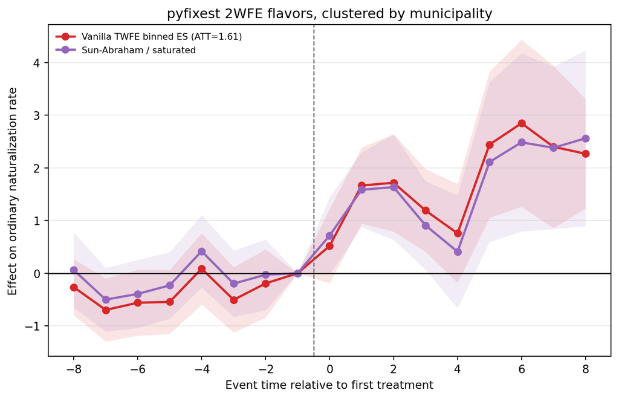

```python
fig, ax = plt.subplots(figsize=(7.5, 4.8), constrained_layout=True)

for label, data, color in [
    (f"Vanilla TWFE binned ES (ATT={twfe_att:.2f})", twfe_event, "tab:red"),
    ("Sun-Abraham / saturated", sa_event, "tab:purple"),
]:
    plot_data = data[(data["event_time"] >= -8) & (data["event_time"] <= 8)].copy()
    x = plot_data["event_time"].to_numpy(float)
    y = plot_data["estimate"].to_numpy(float)
    lo = plot_data["lower"].to_numpy(float)
    hi = plot_data["upper"].to_numpy(float)
    ax.plot(x, y, marker="o", lw=2, color=color, label=label)
    ax.fill_between(x, lo, hi, color=color, alpha=0.12, linewidth=0)

ax.axhline(0, color="black", lw=1)
ax.axvline(-0.5, color="0.4", lw=1, ls="--")
ax.set_title("pyfixest 2WFE flavors, clustered by municipality")
ax.set_xlabel("Event time relative to first treatment")
ax.set_ylabel("Effect on ordinary naturalization rate")
ax.grid(axis="y", alpha=0.25)
ax.legend(frameon=False, fontsize=8, loc="upper left")
plt.show()
```

## 9 Combined Figure

The four panels above are combined into the figure below. The source code is intentionally explicit so each panel can be copied into a separate script or notebook cell.

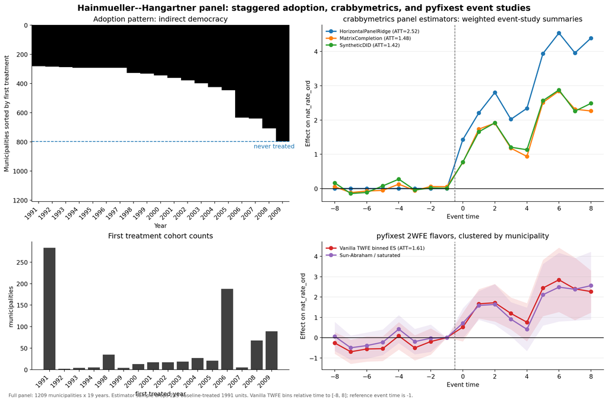

```python
plt.rcParams.update(
    {
        "font.size": 10,
        "axes.spines.top": False,
        "axes.spines.right": False,
    }
)

fig = plt.figure(figsize=(14, 9.2), constrained_layout=True)
grid = fig.add_gridspec(2, 2, width_ratios=[1.05, 1.15], height_ratios=[0.58, 0.42])

ax0 = fig.add_subplot(grid[0, 0])
ax0.imshow(W_sorted, aspect="auto", interpolation="nearest", cmap="Greys", vmin=0, vmax=1)
ax0.set_title("Adoption pattern: indirect democracy")
ax0.set_xlabel("Year")
ax0.set_ylabel("Municipalities sorted by first treatment")
ax0.set_xticks(np.arange(len(years)))
ax0.set_xticklabels(years, rotation=45, ha="right")
ax0.axhline(never_start - 0.5, color="tab:blue", lw=1.2, ls="--")
ax0.text(len(years) - 0.1, never_start + 15, "never treated", color="tab:blue", ha="right", va="top")

ax1 = fig.add_subplot(grid[1, 0])
ax1.bar(np.arange(len(cohort_counts)), cohort_counts.values, color="0.25")
ax1.set_title("First treatment cohort counts")
ax1.set_ylabel("municipalities")
ax1.set_xlabel("first treated year")
ax1.set_xticks(np.arange(len(cohort_counts)))
ax1.set_xticklabels(cohort_counts.index.astype(str), rotation=45, ha="right")

ax2 = fig.add_subplot(grid[0, 1])
for name, result in crabby_results.items():
    mask = (
        (result["event_time"] >= -8)
        & (result["event_time"] <= 8)
        & (result["n"] >= 10)
    )
    ax2.plot(
        result["event_time"][mask],
        result["estimate"][mask],
        marker="o",
        lw=2,
        color=colors[name],
        label=f"{name} (ATT={result['att']:.2f})",
    )
ax2.axhline(0, color="black", lw=1)
ax2.axvline(-0.5, color="0.4", lw=1, ls="--")
ax2.set_title("crabbymetrics panel estimators: weighted event-study summaries")
ax2.set_xlabel("Event time")
ax2.set_ylabel("Effect on nat_rate_ord")
ax2.grid(axis="y", alpha=0.25)
ax2.legend(frameon=False, fontsize=8, loc="upper left")

ax3 = fig.add_subplot(grid[1, 1])
for label, data, color in [
    (f"Vanilla TWFE binned ES (ATT={twfe_att:.2f})", twfe_event, "tab:red"),
    ("Sun-Abraham / saturated", sa_event, "tab:purple"),
]:
    plot_data = data[(data["event_time"] >= -8) & (data["event_time"] <= 8)].copy()
    x = plot_data["event_time"].to_numpy(float)
    y = plot_data["estimate"].to_numpy(float)
    lo = plot_data["lower"].to_numpy(float)
    hi = plot_data["upper"].to_numpy(float)
    ax3.plot(x, y, marker="o", lw=2, color=color, label=label)
    ax3.fill_between(x, lo, hi, color=color, alpha=0.12, linewidth=0)
ax3.axhline(0, color="black", lw=1)
ax3.axvline(-0.5, color="0.4", lw=1, ls="--")
ax3.set_title("pyfixest 2WFE flavors, clustered by municipality")
ax3.set_xlabel("Event time")
ax3.set_ylabel("Effect on nat_rate_ord")
ax3.grid(axis="y", alpha=0.25)
ax3.legend(frameon=False, fontsize=8, loc="upper left")

fig.suptitle(
    "Hainmueller--Hangartner panel: staggered adoption, crabbymetrics, and pyfixest event studies",
    fontsize=14,
    fontweight="bold",
)
fig.text(
    0.01,
    0.005,
    f"Full panel: {Y_all.shape[0]} municipalities x {Y_all.shape[1]} years. "
    f"Estimator sample drops {int((first_idx_all == 0).sum())} baseline-treated 1991 units. "
    "Vanilla TWFE bins relative time to [-8, 8]; reference event time is -1.",
    fontsize=8,
    color="0.35",
)
plt.show()
```

The matrix estimators and the TWFE variants are not estimating identical objects. The matrix estimators use a balanced-panel counterfactual surface and summarize treated-cell effects. For `SyntheticDID`, the plotted event-study gaps come from the unit-weighted synthetic-control path, while the reported scalar ATT also uses the fitted pre-period time weights. The vanilla TWFE event study imposes a pooled dynamic specification with unit and year fixed effects. The saturated pyfixest event study allows cohort-by-event-time heterogeneity before aggregating back to event time.